# Seismophobia Report

Trevor Kinsey, Dustin Andrews, Dustin Burnham, Junghoo Kim 2020/11/26

- Summary
- Introduction
- Methods
- Data
- Analysis
- Results
- References

## Introduction

The damage that earthquakes cause can leave people without food, water, and shelter. Being prepared for an earthquake before it happens can make living through the immediate aftermath less traumatic (Paton, Mcclure, and Buergelt (2006)). Having insurance that covers the damage caused by earthquakes may reduce the uncertainty and fear that the threat of earthquakes creates. People who are afraid of earthquakes represent a group of potential clients for companies selling earthquake preparedness products and insurance. It has been demonstrated that people who are more concerned about earthquakes are more likely to have taken preparatory measures, such as owning a preparedness kit (Dooley et al. 1992).

We aim to predict groups in the population that are afraid of earthquakes and thus are target demographics for advertising. If a machine learning algorithm can identify these groups it enables companies to build a marketing strategy based on this information.

## Data

The data for this analysis was downloaded from https://github.com/fivethirtyeight/data/tree/master/san-andreas. It is based on a survey conducted by [fivethirtyeight.com](https://fivethirtyeight.com/) in May 2015, of 1014 respondents in the US.

The data set contains

- demographic information (age, gender, household income, region of residence in the United States),
- responses to questions relating to knowledge of and experience with earthquakes,
- self-reported level of fear of earthquakes.

Some preliminary examination of the data shows some relation between the demographic features and earthquake fear.

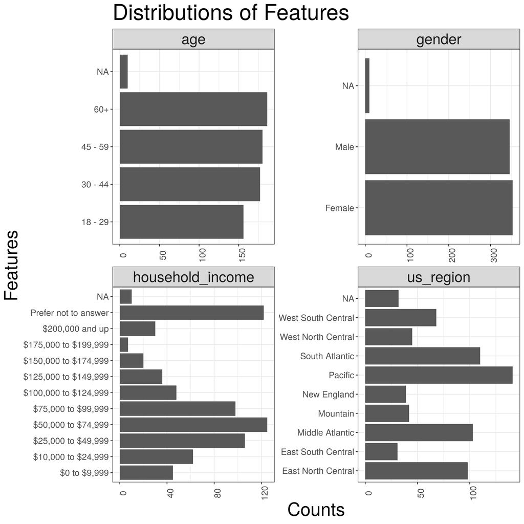

Fig 1: Distribution of demographic information among survey respondents

The survey respondents were fairly evenly split across ages categories and genders. The household income distribution was not uniform, but is likely a reflection of the US population’s income distribution, that had a median value of $55,775 in 2015 (Bureau 2018). The distribution across US regions was not uniform, possibly due to the fact that the list of regions is divided into geographic regions that don’t necessarily have the same populations. For example, the Pacific region (Washington, Oregon, and California) has a population of 50.1 million compared to New England (Connecticut, Massachusetts, Maine, New Hampshire, Rhode Island, and Vermont) has a combined population of 14.7 million (Bureau 2019).

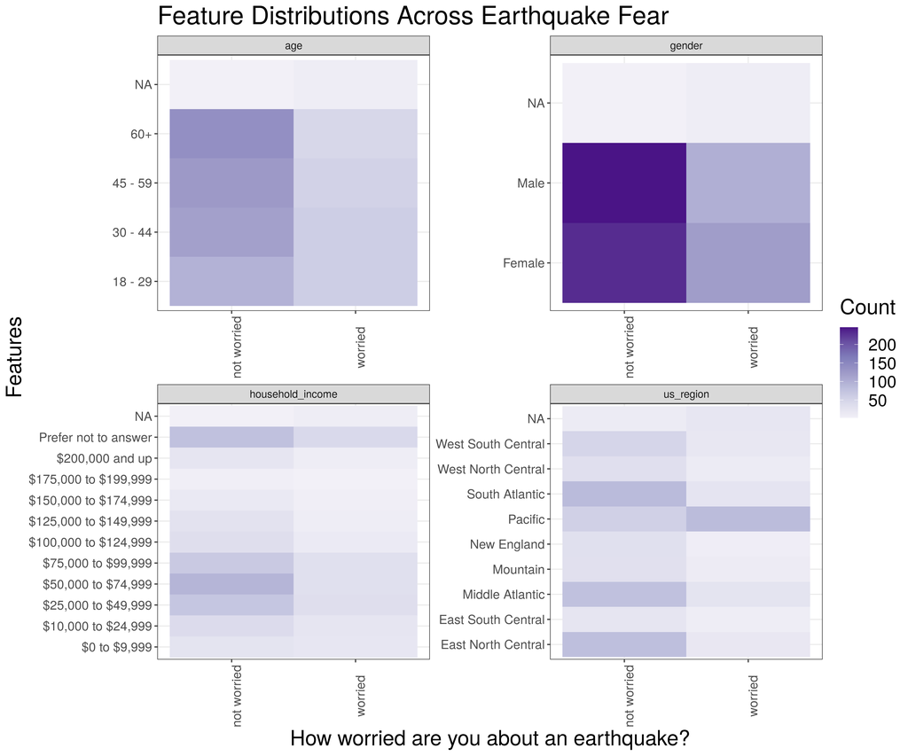

Fig 2: The level of earthquake fear across demograhic features

Younger people tend to report being afraid more often than older people, while women report being afraid more often than men. The geographic region with the highest level of fear is the Pacific. Overall there were more people who were not afraid of earthquakes than were afraid.

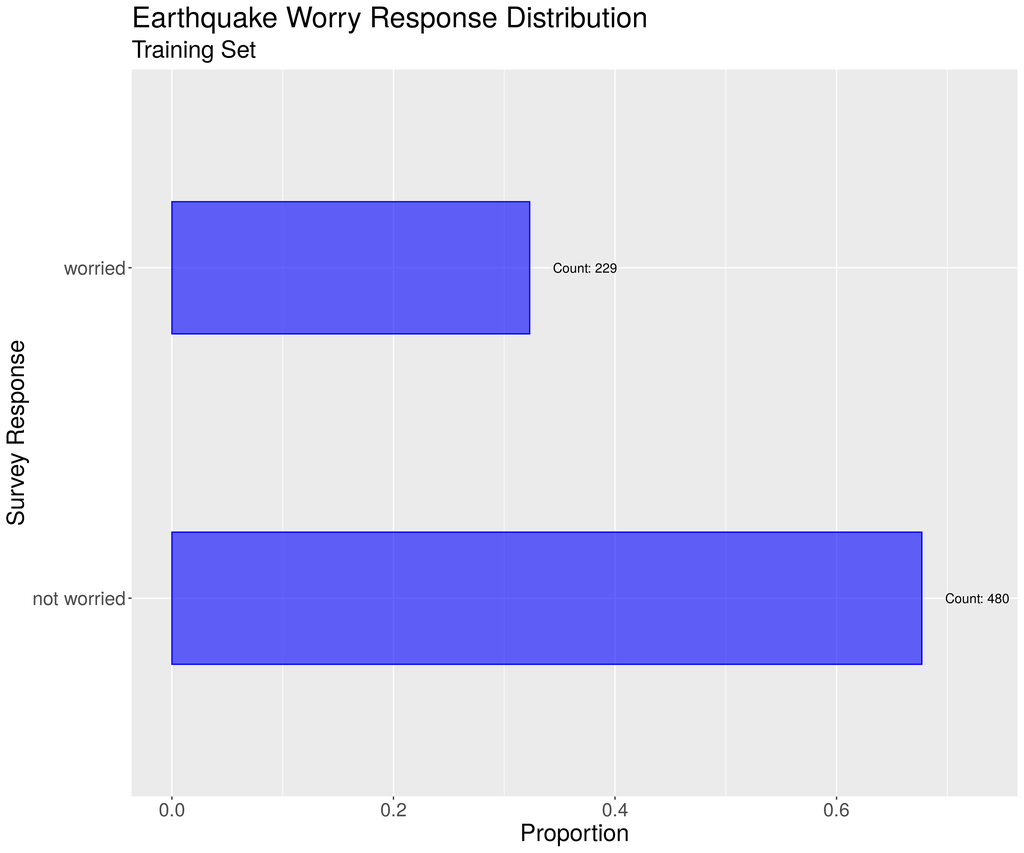

Fig 3: The distribution of earthquake fear among respondents

## Analysis

We used a random forest classifier and a logistic regression for the classification task. In addition to binary classification for prediction, random forest classifier and logistic regression give a measure of importance for each feature. We decided to use SHAP values to investigate feature importance after some preliminary exploration of global feature importance. We chose to use only the demographic variables as model features because they are readily available in census data without having to conduct a separate, more task-specific survey. The prediction target is the self-reported fear of earthquakes, which we converted from an ordinal variable to a binary variable called `target`. The class `target` = 0 includes the levels *“not at all worried”* and *“not so worried”*, while `target` = 1 includes *“somewhat worried”*, *“very worried”*, and *“extremely worried”*.

## Results

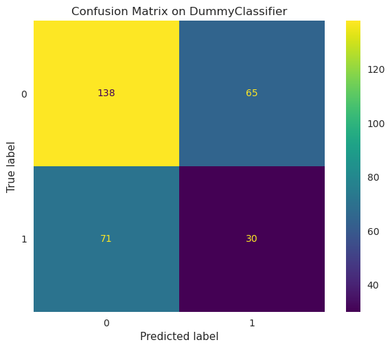

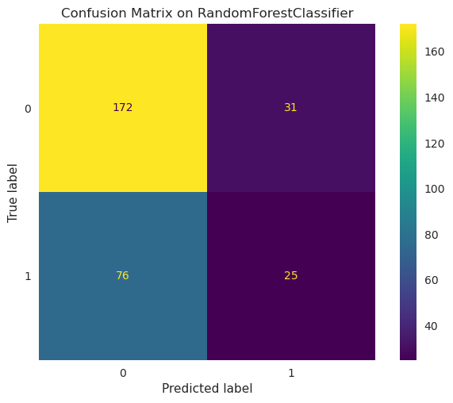

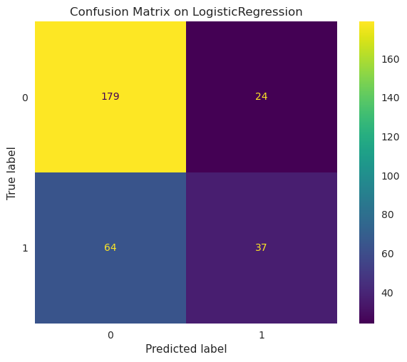

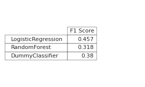

Fig 5: Classifier F1 scores

Of the models positive predictions, a greater proportion were correct than the dummy classifier’s, as characterized by our models higher *ROC AUC* scores. The models predicted better than if it was guessing at random, but not a by lot.

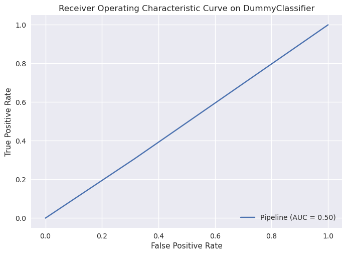

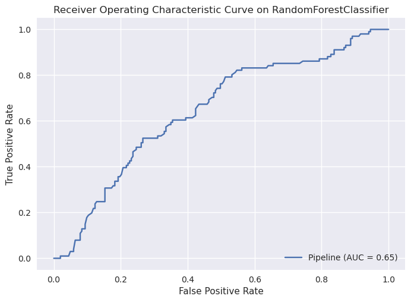

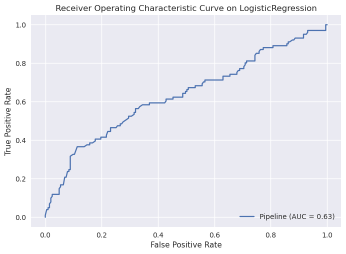

Fig 6: ROC curves for various models

The features that were most important in the prediction task were household income, living in the Pacific region, and age. Digging into these features a bit more - we can look at the SHAP value trends for each input to determine what is driving predictions.

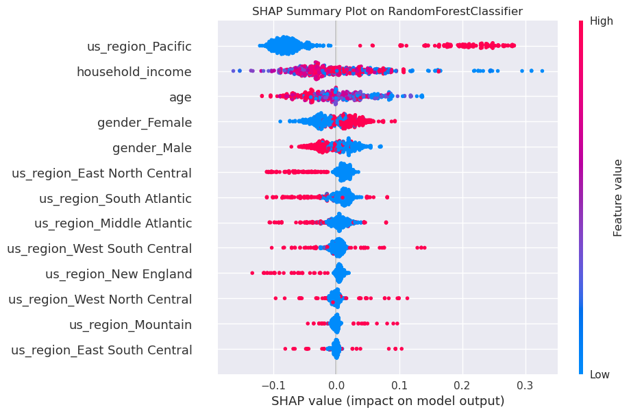

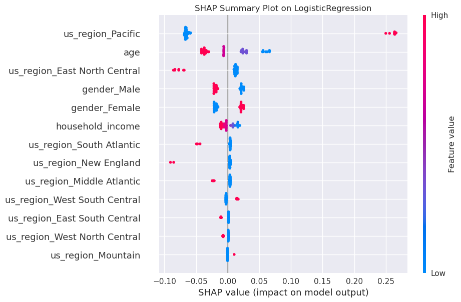

Fig 7: SHAP plot for random forest and logistic regression classifiers

Looking at the SHAP values for `us_region_Pacific`, we can see the significant increase in prediction when people were located in the Pacific area. Utilizing the two variables for gender, it appears our model predicts women are more likely to be afraid of earthquakes than men.

Our models do not seem to be very effective in identifying people who are afraid of earthquakes. The greatest potential for improvement lies in obtaining a more comprehensive data set that contains more demographic features and a larger sample size.

The R (R Core Team 2019) and Python (Van Rossum and Drake Jr 1995) programming languages and the following Python packages were used for this project: pandas (team 2020), sklearn (Pedregosa et al. 2011), tidyverse (Wickham 2017), and knitr (Xie 2014). The code used to perform the analysis and create this report can be found at: https://github.com/UBC-MDS/seismophobia

## References

Bureau, US Census. 2018. “Income and Poverty in the United States: 2015.” *The United States Census Bureau*. https://www.census.gov/library/publications/2016/demo/p60-256.html.

———. 2019. “State Population Totals: 2010-2019.” *The United States Census Bureau*. https://www.census.gov/data/tables/time-series/demo/popest/2010s-state-total.html.

Dooley, David, Ralph Catalano, Shiraz Mishra, and Seth Serxner. 1992. “Earthquake Preparedness: Predictors in a Community Survey1.” *Journal of Applied Social Psychology* 22 (6): 451–70. https://doi.org/https://doi.org/10.1111/j.1559-1816.1992.tb00984.x.

Paton, D, J Mcclure, and Petra Buergelt. 2006. “Natural Hazard Resilience: The Role of Individual and Household Preparedness.” In *Disaster Resilience an Integrated Approach*, edited by Douglas Paton and David Johnston, 105–27. Charles C Thomas Publisher, Ltd.

Pedregosa, F., G. Varoquaux, A. Gramfort, V. Michel, B. Thirion, O. Grisel, M. Blondel, et al. 2011. “Scikit-Learn: Machine Learning in Python.” *Journal of Machine Learning Research* 12: 2825–30.

R Core Team. 2019. *R: A Language and Environment for Statistical Computing*. Vienna, Austria: R Foundation for Statistical Computing. https://www.R-project.org/.

team, The pandas development. 2020. *Pandas-Dev/Pandas: Pandas* (version latest). Zenodo. https://doi.org/10.5281/zenodo.3509134.

Van Rossum, Guido, and Fred L Drake Jr. 1995. *Python Tutorial*. Centrum voor Wiskunde en Informatica Amsterdam, The Netherlands.

Wickham, Hadley. 2017. *Tidyverse: Easily Install and Load the ’Tidyverse’*. https://CRAN.R-project.org/package=tidyverse.

Xie, Yihui. 2014. “Knitr: A Comprehensive Tool for Reproducible Research in R.” In *Implementing Reproducible Computational Research*, edited by Victoria Stodden, Friedrich Leisch, and Roger D. Peng. Chapman; Hall/CRC. http://www.crcpress.com/product/isbn/9781466561595.